# 项目：Medical Appointment

## 目录

- 简介
- 数据整理
- 探索性数据分析
- 结论

## 简介

此次分析数据选自nishowappointment文件，文件中记录了每个预约门诊病人的基本信息、身体状况以及是否前来赴约等信息，我需要在此数据集中探索每个预约者的赴约情况，和各种疾病和年龄或者性别的相关性。

```python
import pandas as pd
import numpy as np
import matplotlib.pyplot as plt
import seaborn as sns
% matplotlib inline
df = pd.read_csv('noshowappointments.csv')
df.head()
```

|  | PatientId | AppointmentID | Gender | ScheduledDay | AppointmentDay | Age | Neighbourhood | Scholarship | Hipertension | Diabetes | Alcoholism | Handcap | SMS_received | No-show |
| --- | --- | --- | --- | --- | --- | --- | --- | --- | --- | --- | --- | --- | --- | --- |
| 0 | 2.987250e+13 | 5642903 | F | 2016-04-29T18:38:08Z | 2016-04-29T00:00:00Z | 62 | JARDIM DA PENHA | 0 | 1 | 0 | 0 | 0 | 0 | No |
| 1 | 5.589978e+14 | 5642503 | M | 2016-04-29T16:08:27Z | 2016-04-29T00:00:00Z | 56 | JARDIM DA PENHA | 0 | 0 | 0 | 0 | 0 | 0 | No |
| 2 | 4.262962e+12 | 5642549 | F | 2016-04-29T16:19:04Z | 2016-04-29T00:00:00Z | 62 | MATA DA PRAIA | 0 | 0 | 0 | 0 | 0 | 0 | No |
| 3 | 8.679512e+11 | 5642828 | F | 2016-04-29T17:29:31Z | 2016-04-29T00:00:00Z | 8 | PONTAL DE CAMBURI | 0 | 0 | 0 | 0 | 0 | 0 | No |
| 4 | 8.841186e+12 | 5642494 | F | 2016-04-29T16:07:23Z | 2016-04-29T00:00:00Z | 56 | JARDIM DA PENHA | 0 | 1 | 1 | 0 | 0 | 0 | No |

## 数据整理

### 常规属性

```python
df.info()
df.isnull().sum()
df.duplicated().sum()
df.dtypes
df.shape
```

```
<class 'pandas.core.frame.DataFrame'>
RangeIndex: 110527 entries, 0 to 110526
Data columns (total 14 columns):
PatientId         110527 non-null float64
AppointmentID     110527 non-null int64
Gender            110527 non-null object
ScheduledDay      110527 non-null object
AppointmentDay    110527 non-null object
Age               110527 non-null int64
Neighbourhood     110527 non-null object
Scholarship       110527 non-null int64
Hipertension      110527 non-null int64
Diabetes          110527 non-null int64
Alcoholism        110527 non-null int64
Handcap           110527 non-null int64
SMS_received      110527 non-null int64
No-show           110527 non-null object
dtypes: float64(1), int64(8), object(5)
memory usage: 11.8+ MB
```

```
(110527, 14)
```

检查文件中数据无空值、重复项，数据类型无错误，为110527行 14列的dataframe

### 数据整理以及规范列名称

```python
df['AppointmentDay'] = df['AppointmentDay'].apply(lambda x:x.strip('T00:00:00Z'))#去除多余后缀
df.head()
```

|  | PatientId | AppointmentID | Gender | ScheduledDay | AppointmentDay | Age | Neighbourhood | Scholarship | Hipertension | Diabetes | Alcoholism | Handcap | SMS_received | No-show |
| --- | --- | --- | --- | --- | --- | --- | --- | --- | --- | --- | --- | --- | --- | --- |
| 0 | 2.987250e+13 | 5642903 | F | 2016-04-29T18:38:08Z | 2016-04-29 | 62 | JARDIM DA PENHA | 0 | 1 | 0 | 0 | 0 | 0 | No |
| 1 | 5.589978e+14 | 5642503 | M | 2016-04-29T16:08:27Z | 2016-04-29 | 56 | JARDIM DA PENHA | 0 | 0 | 0 | 0 | 0 | 0 | No |
| 2 | 4.262962e+12 | 5642549 | F | 2016-04-29T16:19:04Z | 2016-04-29 | 62 | MATA DA PRAIA | 0 | 0 | 0 | 0 | 0 | 0 | No |
| 3 | 8.679512e+11 | 5642828 | F | 2016-04-29T17:29:31Z | 2016-04-29 | 8 | PONTAL DE CAMBURI | 0 | 0 | 0 | 0 | 0 | 0 | No |
| 4 | 8.841186e+12 | 5642494 | F | 2016-04-29T16:07:23Z | 2016-04-29 | 56 | JARDIM DA PENHA | 0 | 1 | 1 | 0 | 0 | 0 | No |

```python
df.rename(columns={'No-show':'No_show'}, inplace=True)#重命名列名
df.columns
```

```
Index(['PatientId', 'AppointmentID', 'Gender', 'ScheduledDay',
       'AppointmentDay', 'Age', 'Neighbourhood', 'Scholarship', 'Hipertension',
       'Diabetes', 'Alcoholism', 'Handcap', 'SMS_received', 'No_show'],
      dtype='object')
```

## 探索性数据分析

### 首先探索预约者接收到短信是否影响赴约

```python
df.describe()
```

|  | PatientId | AppointmentID | Age | Scholarship | Hipertension | Diabetes | Alcoholism | Handcap | SMS_received |
| --- | --- | --- | --- | --- | --- | --- | --- | --- | --- |
| count | 1.105270e+05 | 1.105270e+05 | 110527.000000 | 110527.000000 | 110527.000000 | 110527.000000 | 110527.000000 | 110527.000000 | 110527.000000 |
| mean | 1.474963e+14 | 5.675305e+06 | 37.088874 | 0.098266 | 0.197246 | 0.071865 | 0.030400 | 0.022248 | 0.321026 |
| std | 2.560949e+14 | 7.129575e+04 | 23.110205 | 0.297675 | 0.397921 | 0.258265 | 0.171686 | 0.161543 | 0.466873 |
| min | 3.921784e+04 | 5.030230e+06 | -1.000000 | 0.000000 | 0.000000 | 0.000000 | 0.000000 | 0.000000 | 0.000000 |
| 25% | 4.172614e+12 | 5.640286e+06 | 18.000000 | 0.000000 | 0.000000 | 0.000000 | 0.000000 | 0.000000 | 0.000000 |
| 50% | 3.173184e+13 | 5.680573e+06 | 37.000000 | 0.000000 | 0.000000 | 0.000000 | 0.000000 | 0.000000 | 0.000000 |
| 75% | 9.439172e+13 | 5.725524e+06 | 55.000000 | 0.000000 | 0.000000 | 0.000000 | 0.000000 | 0.000000 | 1.000000 |
| max | 9.999816e+14 | 5.790484e+06 | 115.000000 | 1.000000 | 1.000000 | 1.000000 | 1.000000 | 4.000000 | 1.000000 |

预约者中平均年龄为37岁，有9.82%的人享有Scholarship福利保障，有32%的人收到了预约提醒短信

```python
received_ratio = df.SMS_received.mean()
not_received_ratio = 1 - received_ratio
ratio = np.array([received_ratio, not_received_ratio])
ratio
```

```
array([ 0.32102563,  0.67897437])
```

```
Text(0.5,1,'the ratio of sms_received')
```

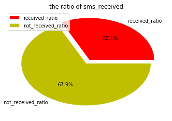

```python
plt.figure(figsize=(6,4))
labels = ['received_ratio','not_received_ratio']
colors =['r','y']
explode = (0.1,0)
plt.pie(ratio,labels=labels,colors=colors,explode=explode,autopct='%3.1f%%')
plt.legend(loc='upper left')
plt.title('the ratio of sms_received')
```

预约者中收到短信提醒的比例是32.10%

```python
show_up = df.query('No_show == "No"')
no_show = df.query('No_show == "Yes"')
show_up_received = show_up['SMS_received'].mean()
no_show_received = no_show['SMS_received'].mean()
```

```python
no_show_received
```

```
0.43837089475334917
```

爽约的预约者中约有43%的人收到了短信提醒

```python
show_up_received
```

```
0.29133411935425357
```

前有赴约的预约者中约有29%%的人收到了短信提醒

```
Text(0,0.5,'sum_received')
```

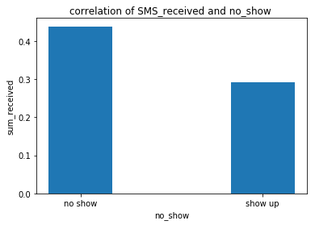

```python
locations = [1,2]
width = 0.35
heights = [no_show_received, show_up_received]
labels = ['no show','show up']
plt.bar(locations, heights, width, tick_label=labels)
plt.title('correlation of SMS_received and no_show ')
plt.xlabel('no_show')
plt.ylabel('sum_received')
```

由上图可知爽约组收到提醒信息的比例较高，说明收到短信对能否如期赴约没有太大关系

### 预约者中患有Hipertension, Diabetes, Alcoholism, Handcap这四种疾病的情况

```python
illness = df.iloc[:,8:-2].sum()/df.shape[0]
illness
```

```
Hipertension    0.197246
Diabetes        0.071865
Alcoholism      0.030400
Handcap         0.022248
dtype: float64
```

预约者中患有Hipertension（高血压）的比例最大

```python
illness.sum()
```

```
0.32175848435223969
```

预约者患病率为32.18%

```python
female = df.query('Gender == "F"')
female.describe()
```

|  | PatientId | AppointmentID | Age | Scholarship | Hipertension | Diabetes | Alcoholism | Handcap | SMS_received |
| --- | --- | --- | --- | --- | --- | --- | --- | --- | --- |
| count | 7.184000e+04 | 7.184000e+04 | 71840.000000 | 71840.000000 | 71840.000000 | 71840.000000 | 71840.000000 | 71840.000000 | 71840.000000 |
| mean | 1.460136e+14 | 5.674337e+06 | 38.893987 | 0.123232 | 0.213516 | 0.078035 | 0.017024 | 0.019543 | 0.336888 |
| std | 2.549561e+14 | 7.201597e+04 | 22.155235 | 0.328706 | 0.409792 | 0.268228 | 0.129361 | 0.150009 | 0.472649 |
| min | 3.921784e+04 | 5.030230e+06 | -1.000000 | 0.000000 | 0.000000 | 0.000000 | 0.000000 | 0.000000 | 0.000000 |
| 25% | 3.974486e+12 | 5.639222e+06 | 21.000000 | 0.000000 | 0.000000 | 0.000000 | 0.000000 | 0.000000 | 0.000000 |
| 50% | 2.987250e+13 | 5.679852e+06 | 39.000000 | 0.000000 | 0.000000 | 0.000000 | 0.000000 | 0.000000 | 0.000000 |
| 75% | 9.395978e+13 | 5.724905e+06 | 56.000000 | 0.000000 | 0.000000 | 0.000000 | 0.000000 | 0.000000 | 1.000000 |
| max | 9.999816e+14 | 5.790484e+06 | 115.000000 | 1.000000 | 1.000000 | 1.000000 | 1.000000 | 4.000000 | 1.000000 |

```python
female_illness = female.iloc[:,8:-2].sum()/female.shape[0]
```

```python
female_morbidity = female_illness.sum()
female_morbidity
```

```
0.32811804008908685
```

女性患病率为32.81%

```python
male = df.query('Gender == "M"')
male.describe()
```

|  | PatientId | AppointmentID | Age | Scholarship | Hipertension | Diabetes | Alcoholism | Handcap | SMS_received |
| --- | --- | --- | --- | --- | --- | --- | --- | --- | --- |
| count | 3.868700e+04 | 3.868700e+04 | 38687.000000 | 38687.000000 | 38687.000000 | 38687.000000 | 38687.000000 | 38687.000000 | 38687.000000 |
| mean | 1.502496e+14 | 5.677102e+06 | 33.736863 | 0.051904 | 0.167033 | 0.060408 | 0.055238 | 0.027270 | 0.291571 |
| std | 2.581770e+14 | 6.990406e+04 | 24.435221 | 0.221836 | 0.373010 | 0.238244 | 0.228448 | 0.180917 | 0.454492 |
| min | 4.374176e+04 | 5.122866e+06 | 0.000000 | 0.000000 | 0.000000 | 0.000000 | 0.000000 | 0.000000 | 0.000000 |
| 25% | 4.346759e+12 | 5.642308e+06 | 10.000000 | 0.000000 | 0.000000 | 0.000000 | 0.000000 | 0.000000 | 0.000000 |
| 50% | 3.336718e+13 | 5.681916e+06 | 33.000000 | 0.000000 | 0.000000 | 0.000000 | 0.000000 | 0.000000 | 0.000000 |
| 75% | 9.488922e+13 | 5.726456e+06 | 54.000000 | 0.000000 | 0.000000 | 0.000000 | 0.000000 | 0.000000 | 1.000000 |
| max | 9.999465e+14 | 5.790466e+06 | 100.000000 | 1.000000 | 1.000000 | 1.000000 | 1.000000 | 4.000000 | 1.000000 |

```python
male_illness = male.iloc[:,8:-2].sum()/male.shape[0]
df.shape[0] == male.shape[0] + female.shape[0]
male_illness
```

```
Hipertension    0.167033
Diabetes        0.060408
Alcoholism      0.055238
Handcap         0.027270
dtype: float64
```

```python
male_morbidity = male_illness.sum()
male_morbidity
```

```
0.30994907850182235
```

男性性患病率为30.99%

```
Text(0,0.5,'morbidity')
```

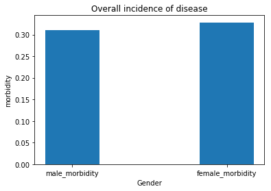

```python
locations = [1,2]
width = 0.35
heights = [male_morbidity, female_morbidity]
labels = ['male_morbidity','female_morbidity']
plt.bar(locations, heights, width, tick_label=labels)
plt.title('Overall incidence of disease')
plt.xlabel('Gender')
plt.ylabel('morbidity')
```

数据表明女性预约者患有这四种疾病之一的比例略高于男性

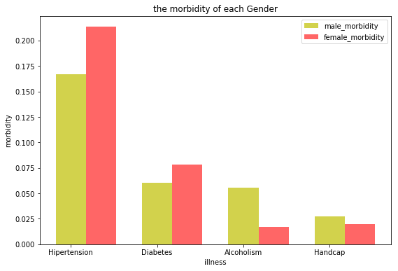

```python
plt.subplots(figsize=(9,6))
ind = np.arange(len(male_illness))
width = 0.35
male_bars = plt.bar(ind, male_illness, width, color='y', alpha=.7, label='male_morbidity')
female_bars = plt.bar(ind+width, female_illness, width, color='r', alpha=.6, label='female_morbidity')
plt.title('the morbidity of each Gender')
plt.xlabel('illness')
plt.ylabel('morbidity')
locations = ind + width/2
labels = ['Hipertension', 'Diabetes', 'Alcoholism', 'Handcap']
plt.xticks(ind, labels)
plt.legend()
# plt.bar()
```

由上图可知，就预约系统中的样本显示女性患有高血压和糖尿病的比例稍高于男性，而男性酒精中毒和残疾的比例比女性高

### 将年龄分成4组

```python
df = df[df['Age'] != -1]
df['Age'].describe()
```

```
count    110526.000000
mean         37.089219
std          23.110026
min           0.000000
25%          18.000000
50%          37.000000
75%          55.000000
max         115.000000
Name: Age, dtype: float64
```

```python
bins = [0,18,37,55,115]
bin_labels  =['teenager','youngster','middle_aged','elderly']
df['age_grades'] = pd.cut(df.Age, bins, labels=bin_labels)
df.head()
```

|  | PatientId | AppointmentID | Gender | ScheduledDay | AppointmentDay | Age | Neighbourhood | Scholarship | Hipertension | Diabetes | Alcoholism | Handcap | SMS_received | No_show | age_grades |
| --- | --- | --- | --- | --- | --- | --- | --- | --- | --- | --- | --- | --- | --- | --- | --- |
| 0 | 2.987250e+13 | 5642903 | F | 2016-04-29T18:38:08Z | 2016-04-29 | 62 | JARDIM DA PENHA | 0 | 1 | 0 | 0 | 0 | 0 | No | elderly |
| 1 | 5.589978e+14 | 5642503 | M | 2016-04-29T16:08:27Z | 2016-04-29 | 56 | JARDIM DA PENHA | 0 | 0 | 0 | 0 | 0 | 0 | No | elderly |
| 2 | 4.262962e+12 | 5642549 | F | 2016-04-29T16:19:04Z | 2016-04-29 | 62 | MATA DA PRAIA | 0 | 0 | 0 | 0 | 0 | 0 | No | elderly |
| 3 | 8.679512e+11 | 5642828 | F | 2016-04-29T17:29:31Z | 2016-04-29 | 8 | PONTAL DE CAMBURI | 0 | 0 | 0 | 0 | 0 | 0 | No | teenager |
| 4 | 8.841186e+12 | 5642494 | F | 2016-04-29T16:07:23Z | 2016-04-29 | 56 | JARDIM DA PENHA | 0 | 1 | 1 | 0 | 0 | 0 | No | elderly |

### 哪个年龄阶段和哪种性别发生的疾病的概率最多

```python
age_group = df.groupby('age_grades').sum().iloc[:,4:8]
age_count = df.groupby('age_grades').count().iloc[:,8:12]
morbidity = age_group.div(age_count)
morbidity['total_morbidity'] = morbidity.apply(lambda x:x.sum(),axis=1)
morbidity
```

| age_grades | Hipertension | Diabetes | Alcoholism | Handcap | total_morbidity |
| --- | --- | --- | --- | --- | --- |
| teenager | 0.001579 | 0.002014 | 0.001106 | 0.012674 | 0.017373 |
| youngster | 0.043119 | 0.012183 | 0.020404 | 0.016183 | 0.091890 |
| middle_aged | 0.239166 | 0.074965 | 0.062291 | 0.022560 | 0.398982 |
| elderly | 0.514507 | 0.201534 | 0.039994 | 0.039594 | 0.795630 |

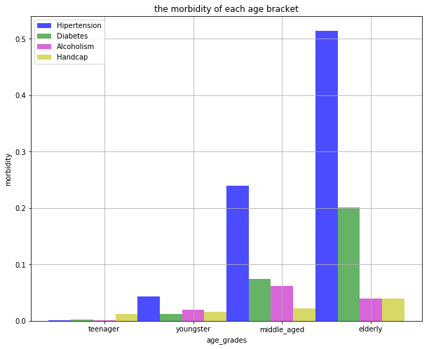

```python
fig, ax = plt.subplots(figsize=(10,8))
# subplots_adjust(left=0.45)#, bottom=None, right=None, top=None, wspace=None, hspace=None)
ind = list(range(4))
width = 0.25
# pos = list(range(len(len(morbidity))))
plt.bar([p + width for p in ind], morbidity['Hipertension'], width, color='b', alpha=.7, label='teenager')
plt.bar([p + width*2 for p in ind], morbidity['Diabetes'], width, color='g', alpha=.6, label='youngste')
plt.bar([p + width*3 for p in ind], morbidity['Alcoholism'], width, color='m', alpha=.6, label='middle')
plt.bar([p + width*4 for p in ind], morbidity['Handcap'], width, color='y', alpha=.6, label='elderly')
# locations = ind + width/2
# labels = ['Hipertension', 'Diabetes', 'Alcoholism', 'Handcap']
# heights = [morbidity.Hipertension,morbidity.Diabetes,morbidity.Alcoholism,morbidity.Handcap]
# plt.bar(locations, heights, tick_labels=labels)
ax.set_title('the morbidity of each age bracket')
ax.set_ylabel('morbidity')
ax.set_xticks([p + 3* width for p in ind])
ax.set_xticklabels(['teenager', 'youngster' ,'middle_aged', 'elderly'])
# labels = ['teenager','youngste','middle','elderly']
# plt.bar(ind, morbidity.total_morbidity, width, color='m', alpha=.7)
# plt.xticks(ind, labels)
# plt.title('the morbidity of each age bracket')
plt.xlabel('age_grades')
plt.ylabel('morbidity')
plt.legend(['Hipertension', 'Diabetes', 'Alcoholism', 'Handcap'], loc='upper left')
plt.grid()
```

## 结论

由于数据提取于医院预约系统，预约者的患病率高于正常人，不具有代表性，仅在同个样本环境下比较不同性别或者年龄的患病率 1，样品数据中，如期赴约的预约者中收到提醒信息的比例比并未比爽约的预约者高，是否收到短信和能否如期赴约可能不具有相关关系 2，数据样本中女性预约者患有这四种疾病之一的比例略高于男性，且在55-115岁即老年期时患有四种疾病之一的概率最高